# 03 데이터 변형 (filter, select, mutate, summarize etc)

```r
library(nycflights13)
library(tidyverse)
```

```r
head(flights)
```

A tibble: 6 × 19

| year <int> | month <int> | day <int> | dep_time <int> | sched_dep_time <int> | dep_delay <dbl> | arr_time <int> | sched_arr_time <int> | arr_delay <dbl> | carrier <chr> | flight <int> | tailnum <chr> | origin <chr> | dest <chr> | air_time <dbl> | distance <dbl> | hour <dbl> | minute <dbl> | time_hour <dttm> |
| --- | --- | --- | --- | --- | --- | --- | --- | --- | --- | --- | --- | --- | --- | --- | --- | --- | --- | --- |
| 2013 | 1 | 1 | 517 | 515 | 2 | 830 | 819 | 11 | UA | 1545 | N14228 | EWR | IAH | 227 | 1400 | 5 | 15 | 2013-01-01 05:00:00 |
| 2013 | 1 | 1 | 533 | 529 | 4 | 850 | 830 | 20 | UA | 1714 | N24211 | LGA | IAH | 227 | 1416 | 5 | 29 | 2013-01-01 05:00:00 |
| 2013 | 1 | 1 | 542 | 540 | 2 | 923 | 850 | 33 | AA | 1141 | N619AA | JFK | MIA | 160 | 1089 | 5 | 40 | 2013-01-01 05:00:00 |
| 2013 | 1 | 1 | 544 | 545 | -1 | 1004 | 1022 | -18 | B6 | 725 | N804JB | JFK | BQN | 183 | 1576 | 5 | 45 | 2013-01-01 05:00:00 |
| 2013 | 1 | 1 | 554 | 600 | -6 | 812 | 837 | -25 | DL | 461 | N668DN | LGA | ATL | 116 | 762 | 6 | 0 | 2013-01-01 06:00:00 |
| 2013 | 1 | 1 | 554 | 558 | -4 | 740 | 728 | 12 | UA | 1696 | N39463 | EWR | ORD | 150 | 719 | 5 | 58 | 2013-01-01 05:00:00 |

## dplyr

- filter() : 값을 기준으로 선택
- arrange() : 행을 재정렬
- select() : 이름으로 변수를 선택
- mutate() : 기존 변수들의 함수로 새로운 변수를 생성
- summarize() : 많은 값을 하나의 요약값으로 합침

### - group_by()와 함께 사용

### filter() : 행 필터링

```r
jan01 <- filter(flights, month == 1, day == 1) # 1월 1일 데이터
```

```r
dec25 <- filter(flights, month == 12, day == 25) # 12월 25일 데이터
```

```r
novdec1 <- filter(flights, month == 11 | month == 12) # 11월 혹은 12월 데이터
novdec2 <- filter(flights, month %in% c(11, 12))
```

```r
# 3.2.4
a <- filter(flights, arr_delay >= 120) # 2시간 이상 도착 지연
b <- filter(flights, dest %in% c("IAH", "HOU")) # 휴스턴으로 운항
c <- filter(flights, carrier %in% c("AA", "DL", "UA")) # 유나이티드, 아메리칸, 델타항공이 운항
d <- filter(flights, month %in% c(7, 8, 9)) # 여름(7, 8, 9)에 출발
e <- filter(flights, arr_delay >= 120 & dep_delay <= 0) # 2시간 이상 지연 도착했지만, 지연 출발하지 않음
f <- filter(flights, dep_delay >= 60, dep_delay - arr_delay > 30) # 최소 한 시간 이상 지연 출발, 운항 중 30분 이상 단축
g <- filter(flights, dep_time <= 600 | dep_time == 2400) # 자정과 6am 사이에 출발
```

```r
# 3.2.5
summer <- filter(flights, between(month, 7, 9)) # 여름 (7, 8, 9)
```

```r
# 3.2.6
sum(is.na(flights$dep_time))
```

8255

### arrange() : 행 정렬

- 결측값은 항상 마지막에 정렬

```r
ar1 <- arrange(flights, year, month, day) # year, month, day순으로 정렬
```

```r
ar2 <- arrange(flights, desc(arr_delay)) # arr_delay 내림차순으로 정렬
```

```r
dim(flights)
```

1. 336776

2. 19

```r
# 3.3.1
a <- arrange(flights, desc(is.na(dep_time)), dep_time) # 모든 결측값을 앞에 오도록
b <- arrange(flights, desc(dep_delay)) # flights를 정렬하여 가장 지연된 항공편(dep_delay)
c <- arrange(flights, arr_delay) # 가장 일찍 출발한 항공편
d <- arrange(flights, sched_arr_time) # 가장 빠른 항공편
e <- arrange(flights, desc(distance)) # 가장 멀리 운항한 항공편
f <- arrange(flights, distance) # 가장 짧게 운항한 항공편
```

### select() : 열 선택

```r
head(select(flights, year, month, day))
```

A tibble: 6 × 3

| year <int> | month <int> | day <int> |
| --- | --- | --- |
| 2013 | 1 | 1 |
| 2013 | 1 | 1 |
| 2013 | 1 | 1 |
| 2013 | 1 | 1 |
| 2013 | 1 | 1 |
| 2013 | 1 | 1 |

```r
head(select(flights, year:day))
```

A tibble: 6 × 3

| year <int> | month <int> | day <int> |
| --- | --- | --- |
| 2013 | 1 | 1 |
| 2013 | 1 | 1 |
| 2013 | 1 | 1 |
| 2013 | 1 | 1 |
| 2013 | 1 | 1 |
| 2013 | 1 | 1 |

```r
head(select(flights, -(year:day)))
```

A tibble: 6 × 16

| dep_time <int> | sched_dep_time <int> | dep_delay <dbl> | arr_time <int> | sched_arr_time <int> | arr_delay <dbl> | carrier <chr> | flight <int> | tailnum <chr> | origin <chr> | dest <chr> | air_time <dbl> | distance <dbl> | hour <dbl> | minute <dbl> | time_hour <dttm> |
| --- | --- | --- | --- | --- | --- | --- | --- | --- | --- | --- | --- | --- | --- | --- | --- |
| 517 | 515 | 2 | 830 | 819 | 11 | UA | 1545 | N14228 | EWR | IAH | 227 | 1400 | 5 | 15 | 2013-01-01 05:00:00 |
| 533 | 529 | 4 | 850 | 830 | 20 | UA | 1714 | N24211 | LGA | IAH | 227 | 1416 | 5 | 29 | 2013-01-01 05:00:00 |
| 542 | 540 | 2 | 923 | 850 | 33 | AA | 1141 | N619AA | JFK | MIA | 160 | 1089 | 5 | 40 | 2013-01-01 05:00:00 |
| 544 | 545 | -1 | 1004 | 1022 | -18 | B6 | 725 | N804JB | JFK | BQN | 183 | 1576 | 5 | 45 | 2013-01-01 05:00:00 |
| 554 | 600 | -6 | 812 | 837 | -25 | DL | 461 | N668DN | LGA | ATL | 116 | 762 | 6 | 0 | 2013-01-01 06:00:00 |
| 554 | 558 | -4 | 740 | 728 | 12 | UA | 1696 | N39463 | EWR | ORD | 150 | 719 | 5 | 58 | 2013-01-01 05:00:00 |

- starts_with("abc") : 'abc'로 시작하는 이름에 매칭
- ends_with("abc") : 'abc'로 끝나는 이름에 매칭
- contains("ijk") : 'ijk'를 포함하는 이름에 매칭
- matches("(.)\1") : 정규표현식에 매칭되는 변술들을 선택,
- num_range("x", 1:3) : x1, x2, x3에 매칭

```r
head(select(flights, time_hour, air_time, everything()))
# time_hour과 air_time변수를 시작부분으로 옮김
```

A tibble: 6 × 19

| time_hour <dttm> | air_time <dbl> | year <int> | month <int> | day <int> | dep_time <int> | sched_dep_time <int> | dep_delay <dbl> | arr_time <int> | sched_arr_time <int> | arr_delay <dbl> | carrier <chr> | flight <int> | tailnum <chr> | origin <chr> | dest <chr> | distance <dbl> | hour <dbl> | minute <dbl> |
| --- | --- | --- | --- | --- | --- | --- | --- | --- | --- | --- | --- | --- | --- | --- | --- | --- | --- | --- |
| 2013-01-01 05:00:00 | 227 | 2013 | 1 | 1 | 517 | 515 | 2 | 830 | 819 | 11 | UA | 1545 | N14228 | EWR | IAH | 1400 | 5 | 15 |
| 2013-01-01 05:00:00 | 227 | 2013 | 1 | 1 | 533 | 529 | 4 | 850 | 830 | 20 | UA | 1714 | N24211 | LGA | IAH | 1416 | 5 | 29 |
| 2013-01-01 05:00:00 | 160 | 2013 | 1 | 1 | 542 | 540 | 2 | 923 | 850 | 33 | AA | 1141 | N619AA | JFK | MIA | 1089 | 5 | 40 |
| 2013-01-01 05:00:00 | 183 | 2013 | 1 | 1 | 544 | 545 | -1 | 1004 | 1022 | -18 | B6 | 725 | N804JB | JFK | BQN | 1576 | 5 | 45 |
| 2013-01-01 06:00:00 | 116 | 2013 | 1 | 1 | 554 | 600 | -6 | 812 | 837 | -25 | DL | 461 | N668DN | LGA | ATL | 762 | 6 | 0 |
| 2013-01-01 05:00:00 | 150 | 2013 | 1 | 1 | 554 | 558 | -4 | 740 | 728 | 12 | UA | 1696 | N39463 | EWR | ORD | 719 | 5 | 58 |

```r
# 3.4.1
# dep_time, dep_delay, arr_time, arr_delay를 선택할 수 있는 방법
select(flights, dep_time, dep_delay, arr_time, arr_delay)
select(flights, 4, 6, 7, 9)

var <- c("dep_time", "dep_delay", "arr_time", "arr_delay")
select(flights, any_of(var))
select(flights, all_of(var))
select(flights, starts_with("dep_"), starts_with("arr_"))
```

```r
# 3.4.3
vars <- c("year", "month", "day", "dep_delay", "arr_delay")
head(select(flights, one_of(vars)))
head(select(flights, any_of(vars)))
head(select(flights, all_of(vars)))
```

```r
# 3.4.4
# "time"문자를 포함하고 있는 열 포함
head(select(flights, contains("TIME")))
```

A tibble: 6 × 6

| dep_time <int> | sched_dep_time <int> | arr_time <int> | sched_arr_time <int> | air_time <dbl> | time_hour <dttm> |
| --- | --- | --- | --- | --- | --- |
| 517 | 515 | 830 | 819 | 227 | 2013-01-01 05:00:00 |
| 533 | 529 | 850 | 830 | 227 | 2013-01-01 05:00:00 |
| 542 | 540 | 923 | 850 | 160 | 2013-01-01 05:00:00 |
| 544 | 545 | 1004 | 1022 | 183 | 2013-01-01 05:00:00 |
| 554 | 600 | 812 | 837 | 116 | 2013-01-01 06:00:00 |
| 554 | 558 | 740 | 728 | 150 | 2013-01-01 05:00:00 |

### mutate() : 새로운 변수 추가

```r
flights_sml <- select(flights, year:day, ends_with("delay"), distance, air_time)
```

```r
head(flights_sml)
```

A tibble: 6 × 7

| year <int> | month <int> | day <int> | dep_delay <dbl> | arr_delay <dbl> | distance <dbl> | air_time <dbl> |
| --- | --- | --- | --- | --- | --- | --- |
| 2013 | 1 | 1 | 2 | 11 | 1400 | 227 |
| 2013 | 1 | 1 | 4 | 20 | 1416 | 227 |
| 2013 | 1 | 1 | 2 | 33 | 1089 | 160 |
| 2013 | 1 | 1 | -1 | -18 | 1576 | 183 |
| 2013 | 1 | 1 | -6 | -25 | 762 | 116 |
| 2013 | 1 | 1 | -4 | 12 | 719 | 150 |

```r
# gain과 speed변수 추가
flights_sml2 <- mutate(flights_sml, gain = arr_delay - dep_delay,
          speed = distance / air_time * 60)
head(flights_sml2)
```

A tibble: 6 × 9

| year <int> | month <int> | day <int> | dep_delay <dbl> | arr_delay <dbl> | distance <dbl> | air_time <dbl> | gain <dbl> | speed <dbl> |
| --- | --- | --- | --- | --- | --- | --- | --- | --- |
| 2013 | 1 | 1 | 2 | 11 | 1400 | 227 | 9 | 370.0441 |
| 2013 | 1 | 1 | 4 | 20 | 1416 | 227 | 16 | 374.2731 |
| 2013 | 1 | 1 | 2 | 33 | 1089 | 160 | 31 | 408.3750 |
| 2013 | 1 | 1 | -1 | -18 | 1576 | 183 | -17 | 516.7213 |
| 2013 | 1 | 1 | -6 | -25 | 762 | 116 | -19 | 394.1379 |
| 2013 | 1 | 1 | -4 | 12 | 719 | 150 | 16 | 287.6000 |

```r
flights_sml3 <- mutate(flights_sml, gain = arr_delay,
                      hours = air_time / 60,
                      gain_per_hour = gain / hours)
head(flights_sml3)
```

A tibble: 6 × 10

| year <int> | month <int> | day <int> | dep_delay <dbl> | arr_delay <dbl> | distance <dbl> | air_time <dbl> | gain <dbl> | hours <dbl> | gain_per_hour <dbl> |
| --- | --- | --- | --- | --- | --- | --- | --- | --- | --- |
| 2013 | 1 | 1 | 2 | 11 | 1400 | 227 | 11 | 3.783333 | 2.907489 |
| 2013 | 1 | 1 | 4 | 20 | 1416 | 227 | 20 | 3.783333 | 5.286344 |
| 2013 | 1 | 1 | 2 | 33 | 1089 | 160 | 33 | 2.666667 | 12.375000 |
| 2013 | 1 | 1 | -1 | -18 | 1576 | 183 | -18 | 3.050000 | -5.901639 |
| 2013 | 1 | 1 | -6 | -25 | 762 | 116 | -25 | 1.933333 | -12.931034 |
| 2013 | 1 | 1 | -4 | 12 | 719 | 150 | 12 | 2.500000 | 4.800000 |

```r
# 새로운 변수만 남기기
flights_sml4 <- transmute(flights, gain = arr_delay,
                          hours = air_time / 60,
                          gain_per_hour = gain / hours)
head(flights_sml4)
```

A tibble: 6 × 3

| gain <dbl> | hours <dbl> | gain_per_hour <dbl> |
| --- | --- | --- |
| 11 | 3.783333 | 2.907489 |
| 20 | 3.783333 | 5.286344 |
| 33 | 2.666667 | 12.375000 |
| -18 | 3.050000 | -5.901639 |
| -25 | 1.933333 | -12.931034 |
| 12 | 2.500000 | 4.800000 |

### 유용한 생성 함수

- 산술연산 : +, -, *, /, ^
- 모듈러 연산 : %/% (몫), %%(나머지)
- 로그 : log(), log2(), log10()
- 오프셋 : lead() (벡터를 앞으로 당김), lag() (벡터를 뒤로 밈)
- 누적 집계 : cumsum(), cumprod(), cummin(), cummax()
- 비교 연산자 : <. <=, >=, >, !=
- 랭킹 : min_rank(), min_rank(desc()), row_number(), dense_rank(), percent_rank(), cume_dist(), ntile()

```r
# 3.5.2
# 가장 지연된 10개의 항공편
mutate(flights, delay = arr_delay + dep_delay) %>%
select(year, month, day, delay) %>%
arrange(desc(delay)) %>% head(10)
```

A tibble: 10 × 4

| year <int> | month <int> | day <int> | delay <dbl> |
| --- | --- | --- | --- |
| 2013 | 1 | 9 | 2573 |
| 2013 | 6 | 15 | 2264 |
| 2013 | 1 | 10 | 2235 |
| 2013 | 9 | 20 | 2021 |
| 2013 | 7 | 22 | 1994 |
| 2013 | 4 | 10 | 1891 |
| 2013 | 3 | 17 | 1826 |
| 2013 | 7 | 22 | 1793 |
| 2013 | 12 | 5 | 1774 |
| 2013 | 5 | 3 | 1753 |

### summarize() : 그룹화 요약

```r
summarize(flights, delay = mean(dep_delay, na.rm = T))
mean(flights$dep_delay, na.rm= T)
```

A tibble: 1 × 1

| delay <dbl> |
| --- |
| 12.63907 |

12.6390702573047

A tibble: 6 × 4

| dest <chr> | count <int> | dist <dbl> | delay <dbl> |
| --- | --- | --- | --- |
| ABQ | 254 | 1826.0000 | 4.381890 |
| ACK | 265 | 199.0000 | 4.852273 |
| ALB | 439 | 143.0000 | 14.397129 |
| ANC | 8 | 3370.0000 | -2.500000 |
| ATL | 17215 | 757.1082 | 11.300113 |
| AUS | 2439 | 1514.2530 | 6.019909 |

A tibble: 6 × 4

| dest <chr> | count <int> | dist <dbl> | delay <dbl> |
| --- | --- | --- | --- |
| ABQ | 254 | 1826.0000 | 4.381890 |
| ACK | 265 | 199.0000 | 4.852273 |
| ALB | 439 | 143.0000 | 14.397129 |
| ATL | 17215 | 757.1082 | 11.300113 |
| AUS | 2439 | 1514.2530 | 6.019909 |
| AVL | 275 | 583.5818 | 8.003831 |

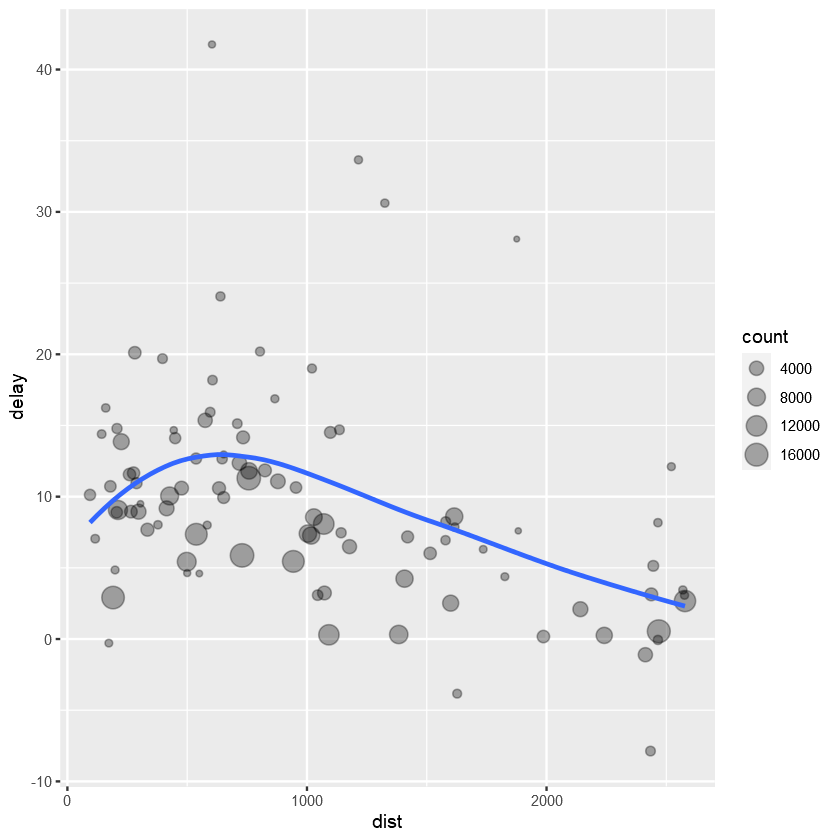

```r
by_dest <- group_by(flights, dest) # 목적지 별로 group
delay <- summarize(by_dest, count = n(), # 목적지별 개수
                  dist = mean(distance, na.rm = T), # 목적지별 평균 거리
                  delay = mean(arr_delay, na.rm = T)) # 목적지별 평균 지연시간
head(delay)
delay <- filter(delay, count > 20, dest != "HNL")
head(delay) # 개수가 20이상, "HNL"이 아닌 목적지만 filter

ggplot(data = delay, aes(x = dist, y = delay)) +
geom_point(aes(size = count), alpha = 1/3) +
geom_smooth(se = F)
```

```r
delays <- flights %>% group_by(dest) %>%
summarize(count = n(),
          dist = mean(distance, na.rm = T),
          delay = mean(arr_delay, na.rm = T)) %>%
filter(count > 20, dest != "HNL")
```

### 결측값

```r
head(flights %>% group_by(year, month ,day) %>% summarize(mean = mean(dep_delay, na.rm = T)))
```

A grouped_df: 6 × 4

| year <int> | month <int> | day <int> | mean <dbl> |
| --- | --- | --- | --- |
| 2013 | 1 | 1 | 11.548926 |
| 2013 | 1 | 2 | 13.858824 |
| 2013 | 1 | 3 | 10.987832 |
| 2013 | 1 | 4 | 8.951595 |
| 2013 | 1 | 5 | 5.732218 |
| 2013 | 1 | 6 | 7.148014 |

### n() : 카운트

```r
not_cancelled <- flights %>% filter(!is.na(dep_delay), !is.na(arr_delay))
head(not_cancelled)
```

A tibble: 6 × 19

| year <int> | month <int> | day <int> | dep_time <int> | sched_dep_time <int> | dep_delay <dbl> | arr_time <int> | sched_arr_time <int> | arr_delay <dbl> | carrier <chr> | flight <int> | tailnum <chr> | origin <chr> | dest <chr> | air_time <dbl> | distance <dbl> | hour <dbl> | minute <dbl> | time_hour <dttm> |
| --- | --- | --- | --- | --- | --- | --- | --- | --- | --- | --- | --- | --- | --- | --- | --- | --- | --- | --- |
| 2013 | 1 | 1 | 517 | 515 | 2 | 830 | 819 | 11 | UA | 1545 | N14228 | EWR | IAH | 227 | 1400 | 5 | 15 | 2013-01-01 05:00:00 |
| 2013 | 1 | 1 | 533 | 529 | 4 | 850 | 830 | 20 | UA | 1714 | N24211 | LGA | IAH | 227 | 1416 | 5 | 29 | 2013-01-01 05:00:00 |
| 2013 | 1 | 1 | 542 | 540 | 2 | 923 | 850 | 33 | AA | 1141 | N619AA | JFK | MIA | 160 | 1089 | 5 | 40 | 2013-01-01 05:00:00 |
| 2013 | 1 | 1 | 544 | 545 | -1 | 1004 | 1022 | -18 | B6 | 725 | N804JB | JFK | BQN | 183 | 1576 | 5 | 45 | 2013-01-01 05:00:00 |
| 2013 | 1 | 1 | 554 | 600 | -6 | 812 | 837 | -25 | DL | 461 | N668DN | LGA | ATL | 116 | 762 | 6 | 0 | 2013-01-01 06:00:00 |
| 2013 | 1 | 1 | 554 | 558 | -4 | 740 | 728 | 12 | UA | 1696 | N39463 | EWR | ORD | 150 | 719 | 5 | 58 | 2013-01-01 05:00:00 |

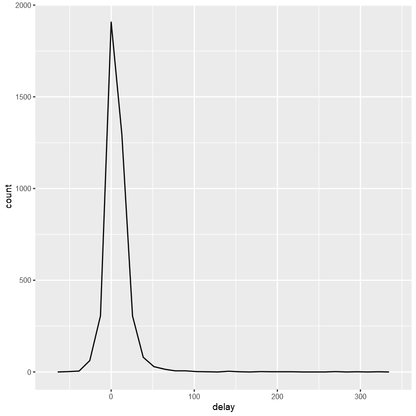

```r
delays <- not_cancelled %>% group_by(tailnum) %>%
summarize(delay = mean(arr_delay))
ggplot(delays) + geom_freqpoly(binswidth = 10, aes(x = delay))
```

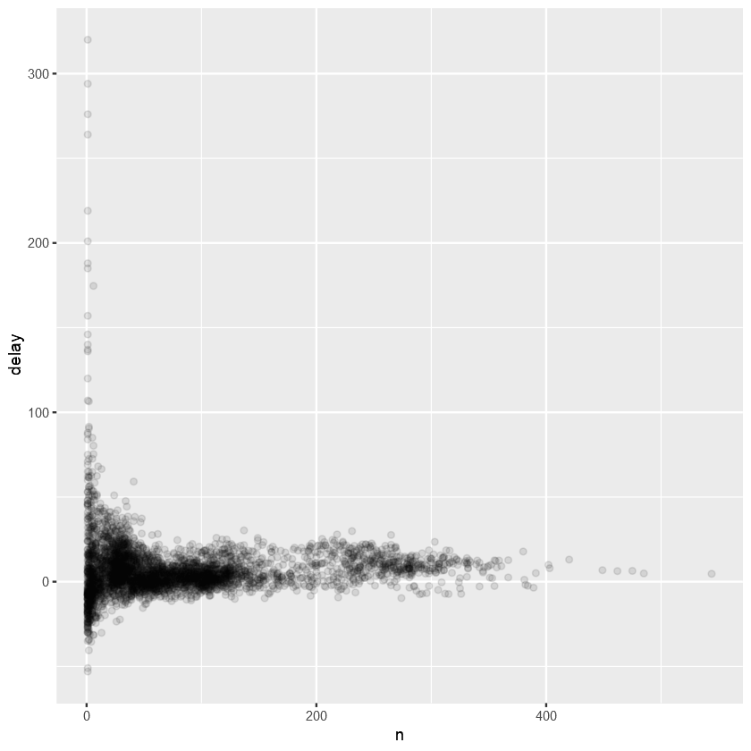

```r
delays <- not_cancelled %>%
group_by(tailnum) %>% summarize(delay = mean(arr_delay, na.rm = T),
                               n = n())
ggplot(delays) + geom_point(aes(x = n, y = delay), alpha = 0.1)
```

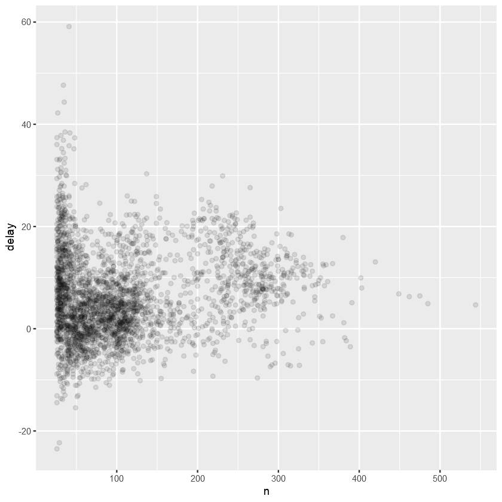

```r
delays %>% filter(n > 25) %>% ggplot(aes(x = n, y = delay)) + geom_point(alpha = 0.1)
```

```r
library(Lahman)
head(Batting)
```

A data.frame: 6 × 22

|  | playerID <chr> | yearID <int> | stint <int> | teamID <fct> | lgID <fct> | G <int> | AB <int> | R <int> | H <int> | X2B <int> | ... | RBI <int> | SB <int> | CS <int> | BB <int> | SO <int> | IBB <int> | HBP <int> | SH <int> | SF <int> | GIDP <int> |
| --- | --- | --- | --- | --- | --- | --- | --- | --- | --- | --- | --- | --- | --- | --- | --- | --- | --- | --- | --- | --- | --- |
| 1 | abercda01 | 1871 | 1 | TRO | NA | 1 | 4 | 0 | 0 | 0 | ... | 0 | 0 | 0 | 0 | 0 | NA | NA | NA | NA | 0 |
| 2 | addybo01 | 1871 | 1 | RC1 | NA | 25 | 118 | 30 | 32 | 6 | ... | 13 | 8 | 1 | 4 | 0 | NA | NA | NA | NA | 0 |
| 3 | allisar01 | 1871 | 1 | CL1 | NA | 29 | 137 | 28 | 40 | 4 | ... | 19 | 3 | 1 | 2 | 5 | NA | NA | NA | NA | 1 |
| 4 | allisdo01 | 1871 | 1 | WS3 | NA | 27 | 133 | 28 | 44 | 10 | ... | 27 | 1 | 1 | 0 | 2 | NA | NA | NA | NA | 0 |
| 5 | ansonca01 | 1871 | 1 | RC1 | NA | 25 | 120 | 29 | 39 | 11 | ... | 16 | 6 | 2 | 2 | 1 | NA | NA | NA | NA | 0 |
| 6 | armstbo01 | 1871 | 1 | FW1 | NA | 12 | 49 | 9 | 11 | 2 | ... | 5 | 0 | 1 | 0 | 1 | NA | NA | NA | NA | 0 |

```r
batting <- as_tibble(Batting)
batters <- batting %>% group_by(playerID) %>%
summarize(ba = sum(H, na.rm = T) / sum(AB, na.rm = T),
         ab = sum(AB, na.rm = T))
head(batters)
```

A tibble: 6 × 3

| playerID <chr> | ba <dbl> | ab <int> |
| --- | --- | --- |
| aardsda01 | 0.0000000 | 4 |
| aaronha01 | 0.3049984 | 12364 |
| aaronto01 | 0.2288136 | 944 |
| aasedo01 | 0.0000000 | 5 |
| abadan01 | 0.0952381 | 21 |
| abadfe01 | 0.1111111 | 9 |

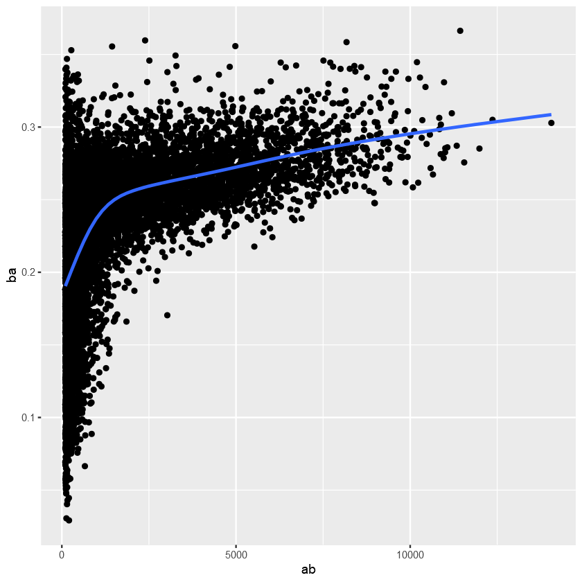

```r
batters %>% filter(ab > 100) %>%
ggplot(aes(x = ab, y = ba)) + geom_point() + geom_smooth(se = F)
```

- 요약함수 : mean, count, sum, median
- 산포 측정값 : sd(표준편차), IQR(사분위범위), mad(중위절대편차)
- 순위 측정값 : min, quantile(x, p), max
- 지리 측정값 : first, nth(x, 2), last
- 유일값 개수 : n_distinct(x)

```r
a <- not_cancelled %>% group_by(year, month ,day) %>%
summarize(avg_delay = mean(arr_delay),
         avg_delay = mean(arr_delay[arr_delay > 0]))
head(a)
```

A grouped_df: 6 × 4

| year <int> | month <int> | day <int> | avg_delay <dbl> |
| --- | --- | --- | --- |
| 2013 | 1 | 1 | 32.48156 |
| 2013 | 1 | 2 | 32.02991 |
| 2013 | 1 | 3 | 27.66087 |
| 2013 | 1 | 4 | 28.30976 |
| 2013 | 1 | 5 | 22.55882 |
| 2013 | 1 | 6 | 24.37270 |

```r
head(not_cancelled %>% group_by(year, month, day) %>%
mutate(r = min_rank(desc(dep_time))) %>%
filter(r %in% range(r)))
```

A grouped_df: 6 × 20

| year <int> | month <int> | day <int> | dep_time <int> | sched_dep_time <int> | dep_delay <dbl> | arr_time <int> | sched_arr_time <int> | arr_delay <dbl> | carrier <chr> | flight <int> | tailnum <chr> | origin <chr> | dest <chr> | air_time <dbl> | distance <dbl> | hour <dbl> | minute <dbl> | time_hour <dttm> | r <int> |
| --- | --- | --- | --- | --- | --- | --- | --- | --- | --- | --- | --- | --- | --- | --- | --- | --- | --- | --- | --- |
| 2013 | 1 | 1 | 517 | 515 | 2 | 830 | 819 | 11 | UA | 1545 | N14228 | EWR | IAH | 227 | 1400 | 5 | 15 | 2013-01-01 05:00:00 | 831 |
| 2013 | 1 | 1 | 2356 | 2359 | -3 | 425 | 437 | -12 | B6 | 727 | N588JB | JFK | BQN | 186 | 1576 | 23 | 59 | 2013-01-01 23:00:00 | 1 |
| 2013 | 1 | 2 | 42 | 2359 | 43 | 518 | 442 | 36 | B6 | 707 | N580JB | JFK | SJU | 189 | 1598 | 23 | 59 | 2013-01-02 23:00:00 | 928 |
| 2013 | 1 | 2 | 2354 | 2359 | -5 | 413 | 437 | -24 | B6 | 727 | N789JB | JFK | BQN | 180 | 1576 | 23 | 59 | 2013-01-02 23:00:00 | 1 |
| 2013 | 1 | 3 | 32 | 2359 | 33 | 504 | 442 | 22 | B6 | 707 | N763JB | JFK | SJU | 193 | 1598 | 23 | 59 | 2013-01-03 23:00:00 | 900 |
| 2013 | 1 | 3 | 2349 | 2359 | -10 | 434 | 445 | -11 | B6 | 739 | N729JB | JFK | PSE | 199 | 1617 | 23 | 59 | 2013-01-03 23:00:00 | 1 |

```r
not_cancelled %>% count(tailnum, wt = distance) %>% head()
# 항공기가 비행한 마일 수의 합
```

A tibble: 6 × 2

| tailnum <chr> | n <dbl> |
| --- | --- |
| D942DN | 3418 |
| N0EGMQ | 239143 |
| N10156 | 109664 |
| N102UW | 25722 |
| N103US | 24619 |
| N104UW | 24616 |

### 여러 변수로 그룹화

```r
daily <- flights %>% group_by(year, month, day)
head(daily)
```

A grouped_df: 6 × 19

| year <int> | month <int> | day <int> | dep_time <int> | sched_dep_time <int> | dep_delay <dbl> | arr_time <int> | sched_arr_time <int> | arr_delay <dbl> | carrier <chr> | flight <int> | tailnum <chr> | origin <chr> | dest <chr> | air_time <dbl> | distance <dbl> | hour <dbl> | minute <dbl> | time_hour <dttm> |
| --- | --- | --- | --- | --- | --- | --- | --- | --- | --- | --- | --- | --- | --- | --- | --- | --- | --- | --- |
| 2013 | 1 | 1 | 517 | 515 | 2 | 830 | 819 | 11 | UA | 1545 | N14228 | EWR | IAH | 227 | 1400 | 5 | 15 | 2013-01-01 05:00:00 |
| 2013 | 1 | 1 | 533 | 529 | 4 | 850 | 830 | 20 | UA | 1714 | N24211 | LGA | IAH | 227 | 1416 | 5 | 29 | 2013-01-01 05:00:00 |
| 2013 | 1 | 1 | 542 | 540 | 2 | 923 | 850 | 33 | AA | 1141 | N619AA | JFK | MIA | 160 | 1089 | 5 | 40 | 2013-01-01 05:00:00 |
| 2013 | 1 | 1 | 544 | 545 | -1 | 1004 | 1022 | -18 | B6 | 725 | N804JB | JFK | BQN | 183 | 1576 | 5 | 45 | 2013-01-01 05:00:00 |
| 2013 | 1 | 1 | 554 | 600 | -6 | 812 | 837 | -25 | DL | 461 | N668DN | LGA | ATL | 116 | 762 | 6 | 0 | 2013-01-01 06:00:00 |
| 2013 | 1 | 1 | 554 | 558 | -4 | 740 | 728 | 12 | UA | 1696 | N39463 | EWR | ORD | 150 | 719 | 5 | 58 | 2013-01-01 05:00:00 |

```r
per_day <- summarize(daily, flights = n()) # 일별 비행 횟수
head(per_day)
```

A grouped_df: 6 × 4

| year <int> | month <int> | day <int> | flights <int> |
| --- | --- | --- | --- |
| 2013 | 1 | 1 | 842 |
| 2013 | 1 | 2 | 943 |
| 2013 | 1 | 3 | 914 |
| 2013 | 1 | 4 | 915 |
| 2013 | 1 | 5 | 720 |
| 2013 | 1 | 6 | 832 |

```r
per_month <- summarize(per_day, flights = sum(flights)) # 월별 비행횟수
head(per_month)
```

A grouped_df: 6 × 3

| year <int> | month <int> | flights <int> |
| --- | --- | --- |
| 2013 | 1 | 27004 |
| 2013 | 2 | 24951 |
| 2013 | 3 | 28834 |
| 2013 | 4 | 28330 |
| 2013 | 5 | 28796 |
| 2013 | 6 | 28243 |

```r
per_year <- summarize(per_month, flights = sum(flights)) # 연간 비행횟수
head(per_year)
```

A tibble: 1 × 2

| year <int> | flights <int> |
| --- | --- |
| 2013 | 336776 |

### 그룹화 해제

```r
daily %>% ungroup() %>% summarize(flights = n())
```

A tibble: 1 × 1

| flights <int> |
| --- |
| 336776 |

```r
# 3.6.7
head(flights %>% count(dest, sort = T))
```

A tibble: 6 × 2

| dest <chr> | n <int> |
| --- | --- |
| ORD | 17283 |
| ATL | 17215 |
| LAX | 16174 |
| BOS | 15508 |
| MCO | 14082 |
| CLT | 14064 |

### 그룹화 mutate

```r
head(flights_sml)
```

A tibble: 6 × 7

| year <int> | month <int> | day <int> | dep_delay <dbl> | arr_delay <dbl> | distance <dbl> | air_time <dbl> |
| --- | --- | --- | --- | --- | --- | --- |
| 2013 | 1 | 1 | 2 | 11 | 1400 | 227 |
| 2013 | 1 | 1 | 4 | 20 | 1416 | 227 |
| 2013 | 1 | 1 | 2 | 33 | 1089 | 160 |
| 2013 | 1 | 1 | -1 | -18 | 1576 | 183 |
| 2013 | 1 | 1 | -6 | -25 | 762 | 116 |
| 2013 | 1 | 1 | -4 | 12 | 719 | 150 |

```r
a <- flights_sml %>% group_by(year, month ,day) %>%
filter(rank(desc(arr_delay)) < 10)
head(a)
```

A grouped_df: 6 × 7

| year <int> | month <int> | day <int> | dep_delay <dbl> | arr_delay <dbl> | distance <dbl> | air_time <dbl> |
| --- | --- | --- | --- | --- | --- | --- |
| 2013 | 1 | 1 | 853 | 851 | 184 | 41 |
| 2013 | 1 | 1 | 290 | 338 | 1134 | 213 |
| 2013 | 1 | 1 | 260 | 263 | 266 | 46 |
| 2013 | 1 | 1 | 157 | 174 | 213 | 60 |
| 2013 | 1 | 1 | 216 | 222 | 708 | 121 |
| 2013 | 1 | 1 | 255 | 250 | 589 | 115 |

```r
popular_dests <- flights %>% group_by(dest) %>%
filter(n() > 365)
head(popular_dests)
```

A grouped_df: 6 × 19

| year <int> | month <int> | day <int> | dep_time <int> | sched_dep_time <int> | dep_delay <dbl> | arr_time <int> | sched_arr_time <int> | arr_delay <dbl> | carrier <chr> | flight <int> | tailnum <chr> | origin <chr> | dest <chr> | air_time <dbl> | distance <dbl> | hour <dbl> | minute <dbl> | time_hour <dttm> |
| --- | --- | --- | --- | --- | --- | --- | --- | --- | --- | --- | --- | --- | --- | --- | --- | --- | --- | --- |
| 2013 | 1 | 1 | 517 | 515 | 2 | 830 | 819 | 11 | UA | 1545 | N14228 | EWR | IAH | 227 | 1400 | 5 | 15 | 2013-01-01 05:00:00 |
| 2013 | 1 | 1 | 533 | 529 | 4 | 850 | 830 | 20 | UA | 1714 | N24211 | LGA | IAH | 227 | 1416 | 5 | 29 | 2013-01-01 05:00:00 |
| 2013 | 1 | 1 | 542 | 540 | 2 | 923 | 850 | 33 | AA | 1141 | N619AA | JFK | MIA | 160 | 1089 | 5 | 40 | 2013-01-01 05:00:00 |
| 2013 | 1 | 1 | 544 | 545 | -1 | 1004 | 1022 | -18 | B6 | 725 | N804JB | JFK | BQN | 183 | 1576 | 5 | 45 | 2013-01-01 05:00:00 |
| 2013 | 1 | 1 | 554 | 600 | -6 | 812 | 837 | -25 | DL | 461 | N668DN | LGA | ATL | 116 | 762 | 6 | 0 | 2013-01-01 06:00:00 |
| 2013 | 1 | 1 | 554 | 558 | -4 | 740 | 728 | 12 | UA | 1696 | N39463 | EWR | ORD | 150 | 719 | 5 | 58 | 2013-01-01 05:00:00 |

```r
popular_dests %>% filter(arr_delay > 0) %>%
mutate(prop_delay = arr_delay / sum(arr_delay)) %>%
select(year:day, dest, arr_delay, prop_delay) %>% head()
```

A grouped_df: 6 × 6

| year <int> | month <int> | day <int> | dest <chr> | arr_delay <dbl> | prop_delay <dbl> |
| --- | --- | --- | --- | --- | --- |
| 2013 | 1 | 1 | IAH | 11 | 1.106740e-04 |
| 2013 | 1 | 1 | IAH | 20 | 2.012255e-04 |
| 2013 | 1 | 1 | MIA | 33 | 2.350026e-04 |
| 2013 | 1 | 1 | ORD | 12 | 4.239594e-05 |
| 2013 | 1 | 1 | FLL | 19 | 9.377853e-05 |
| 2013 | 1 | 1 | ORD | 8 | 2.826396e-05 |